# Homework 4

Vedant Grover

## Problems

### 1

Suppose you have a random variable $X \sim \text{Binomial}(120, 0.15)$.

#### 1A

Calculate and report the mean and standard deviation of the distribution.

```r
# insert code below
n <- 120
p <- 0.15

mean <- n * p
sd <- sqrt(n*p*(1-p))
cat("mean:", mean, ", standard deviation:", sd)
```

```
## mean: 18 , standard deviation: 3.911521
```

#### 1B

Calculate and report the probability that X=20, $P(X = 20)$.

```r
# insert code below
n <- 120
p <- 0.15
x <- 20

prob <- dbinom(x, n, p)

cat("The probability is: ", prob)
```

```
## The probability is:  0.08570049
```

#### 1C

Calculate and report the probability that X>=20, $P(X >= 20)$.

```r
# insert code below
n <- 120
p <- 0.15
x <- 20

prob <- 1 - dbinom(x - 1, n, p)

cat("The probability is: ", prob)
```

```
## The probability is:  0.9038344
```

#### 1D

Create a graph which displays the binomial distribution of X using vertical segments at each value of X=x, where the height of the segments indicate the probability P(X=x).

- For X >= 20, use a different color for the segments from the rest to help visualize your answer to 1C.
- Only display values on the plot for X <= 50
- You may use functions from `ggprob.R`, or create the graphic using your own code.

(If you want to use `ggprob.R` functions, see discussion 4 file for more specific hints and guidance on the functions.)

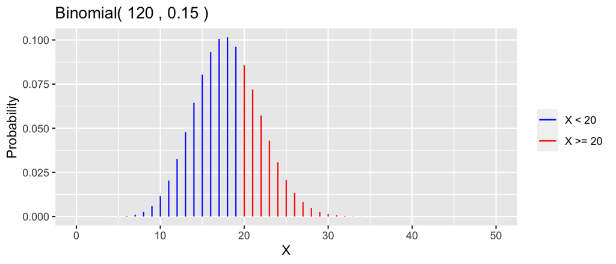

```r
n <- 120
p <- 0.15
x_max <- 50

# Calculate probabilities for X = 0 to x_max
x_values <- 0:x_max
probabilities <- dbinom(x_values, n, p)

# Data frame to store the x and y values
data <- data.frame(x = x_values, prob = probabilities)

ggplot(data, aes(x = x, y = prob)) +
  # For X >= 20, use a different color for the segments
  geom_segment(data = data[data$x >= 20, ], aes(xend = x, yend = 0, color = "X >= 20")) +
  geom_segment(data = data[data$x < 20, ], aes(xend = x, yend = 0, color = "X < 20")) +
  scale_color_manual(values = c("X < 20" = "blue", "X >= 20" = "red")) +
  xlim(0, x_max) +
  xlab('X') +
  ylab('Probability') +
  ggtitle(paste("Binomial(", n, ",", p, ")")) +
  guides(color = guide_legend(title = NULL))
```

### 2

What is the probability that $X$ from Question 1 is within one, two, and three standard deviations of the mean? Round each probability to four decimal places.

```r
# insert code below


n <- 120
p <- 0.15

mean <- n * p
sd <- sqrt(n * p * (1 - p))

prob_within_one_sd <- pbinom(round(mean + sd), n, p) - pbinom(round(mean - sd), n, p)
prob_within_two_sd <- pbinom(round(mean + 2 * sd), n, p) - pbinom(round(mean - 2 * sd), n, p)
prob_within_three_sd <- pbinom(round(mean + 3 * sd), n, p) - pbinom(round(mean - 3 * sd), n, p)

# Round probabilities to four decimal places
prob_within_one_sd <- round(prob_within_one_sd, 4)
prob_within_two_sd <- round(prob_within_two_sd, 4)
prob_within_three_sd <- round(prob_within_three_sd, 4)

cat("Probability within one standard deviation of the mean:", prob_within_one_sd, "\n")
```

```
## Probability within one standard deviation of the mean: 0.6866
```

```r
cat("Probability within two standard deviations of the mean:", prob_within_two_sd, "\n")
```

```
## Probability within two standard deviations of the mean: 0.9597
```

```r
cat("Probability within three standard deviations of the mean:", prob_within_three_sd, "\n")
```

```
## Probability within three standard deviations of the mean: 0.9981
```

### 3

Draw a graph of the binomial distribution from Questions 1 and 2 (similar to what you did in Question 1D with the vertical segments). You may use functions from `ggprob.R`, or create the graphic using your own code. Only display values for X between 5 and 35.

Add vertical lines with different line types at the end points of the intervals 1, 2, and 3 sigma from the mean:

- solid for $\mu \pm \sigma$
- dashed for $\mu \pm 2\sigma$
- dotted for $\mu \pm 3\sigma$

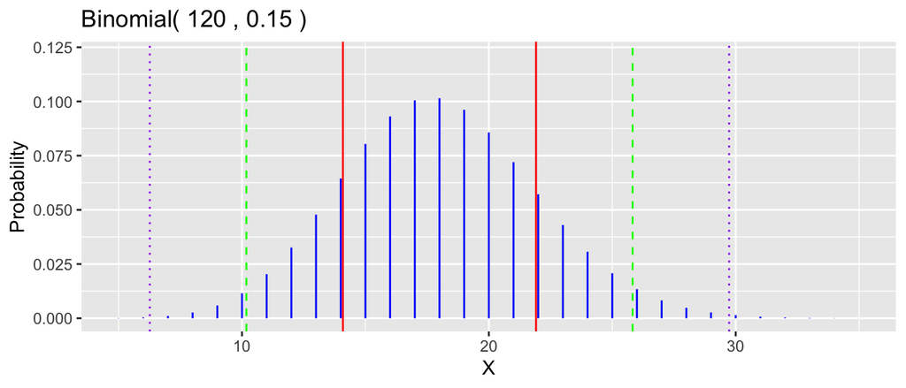

```r
# insert code below
n <- 120
p <- 0.15
x_min <- 5
x_max <- 35

mean_X <- n * p
sd_X <- sqrt(n * p * (1 - p))

x_values <- x_min:x_max
probabilities <- dbinom(x_values, n, p)

data <- data.frame(x = x_values, prob = probabilities)

ggplot(data, aes(x = x, y = prob)) +
  geom_segment(aes(xend = x, yend = 0), color = "blue") +
  geom_vline(xintercept = c(mean_X - sd_X, mean_X + sd_X), linetype = "solid", color = "red") +
  geom_vline(xintercept = c(mean_X - 2 * sd_X, mean_X + 2 * sd_X), linetype = "dashed", color = "green") +
  geom_vline(xintercept = c(mean_X - 3 * sd_X, mean_X + 3 * sd_X), linetype = "dotted", color = "purple") +
  # Plot limits
  xlim(x_min, x_max) +
  ylim(0, max(probabilities) + 0.02) +
  xlab('X') +
  ylab('Probability') +
  ggtitle(paste("Binomial(", n, ",", p, ")")) +
  guides(color = guide_legend(title = NULL))
```

### 4

#### 4A

```r
n <- 100
# Probability of the coin landing heads assuming it is fair
p_fair <- 0.5
heads_observed <- 35

prob_30_or_fewer_heads <- pbinom(heads_observed, n, p_fair)

cat("Probability of observing 30 heads or fewer assuming the coin is fair:", prob_30_or_fewer_heads, "\n")
```

```
## Probability of observing 30 heads or fewer assuming the coin is fair: 0.001758821
```

### 5

#### 5A

Create a tibble where each row corresponds to a binomial distribution with the following columns:

- `n` for $n = 1000,1005,1010, 1015, \ldots, 25,000$
- `p` equal to 0.25 for each row
- `mu` equal to the mean
- `sigma` equal to the standard deviation
- `q.90` equal to the 0.90 quantile of the distribution
- `z = (q.90 - mu)/sigma`, the standardized z-score of the quantile
- `prob` equal to $P(X \ge q.90)$, a right-tail probability for the distribution in each row

Display all columns and the rows of this table for which $n$ is a multiple of 5000.

```r
# insert code below

calculate_quantile_z_prob <- function(n, p) {
  mu <- n * p
  sigma <- sqrt(n * p * (1 - p))
  q_90 <- qbinom(0.9, n, p)
  z_score <- (q_90 - mu) / sigma
  prob_right_tail <- 1 - pbinom(q_90 - 1, n, p)

  tibble(n = n, p = p, mu = mu, sigma = sigma, q_90 = q_90, z = z_score, prob = prob_right_tail)
}

# Tibble for n = 1000 to 25000
result_tibble <- tibble() %>%
  bind_rows(calculate_quantile_z_prob(1000, 0.25)) %>%
  bind_rows(calculate_quantile_z_prob(1005, 0.25)) %>%
  bind_rows(calculate_quantile_z_prob(1010, 0.25)) %>%
  bind_rows(calculate_quantile_z_prob(1015, 0.25)) %>%
  bind_rows(calculate_quantile_z_prob(1020, 0.25)) %>%
  # Add more rows with seq() function
  bind_rows(seq(5000, 25000, by = 5000) %>%
              map_df(~calculate_quantile_z_prob(., 0.25)))

result_filtered <- result_tibble %>%
  filter(n %% 5000 == 0)

print(result_filtered)
```

```
## # A tibble: 5 × 7
##       n     p    mu sigma  q_90     z  prob
##   <dbl> <dbl> <dbl> <dbl> <dbl> <dbl> <dbl>
## 1  5000  0.25  1250  30.6  1289  1.27 0.105
## 2 10000  0.25  2500  43.3  2556  1.29 0.100
## 3 15000  0.25  3750  53.0  3818  1.28 0.102
## 4 20000  0.25  5000  61.2  5079  1.29 0.100
## 5 25000  0.25  6250  68.5  6338  1.29 0.101
```

#### 5B

Use a line plot to show the relationship between $n$ on the x axis and $z$ on the y axis. Add a smooth curve to highlight the trend. Describe the pattern you see.

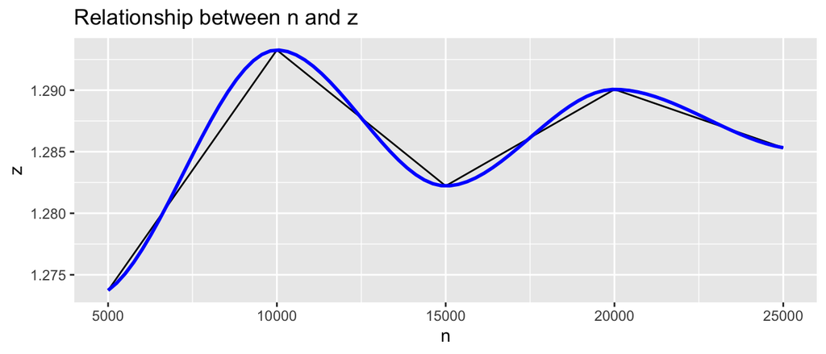

```r
# insert code below
# Load required libraries

# Plot the relationship between n and z with a smooth curve
ggplot(result_filtered, aes(x = n, y = z)) +
  geom_line() +
  geom_smooth(method = "loess", se = FALSE, color = "blue") +
  xlab("n") +
  ylab("z") +
  ggtitle("Relationship between n and z")
```

#### 5C

What is the average of the values of $z$ for $n > 15,000$?

```r
# insert code below

filtered_data <- data %>%
  filter(n > 15000)

average_z_for_n_gt_15000 <- mean(filtered_data$z)
cat("Average of 'z' values for n > 15,000:", average_z_for_n_gt_15000, "\n")
```

```
## Average of 'z' values for n > 15,000: NA
```

#### 5D

Plot the right tail probability `prob` on y axis versus `n` on the x axis.

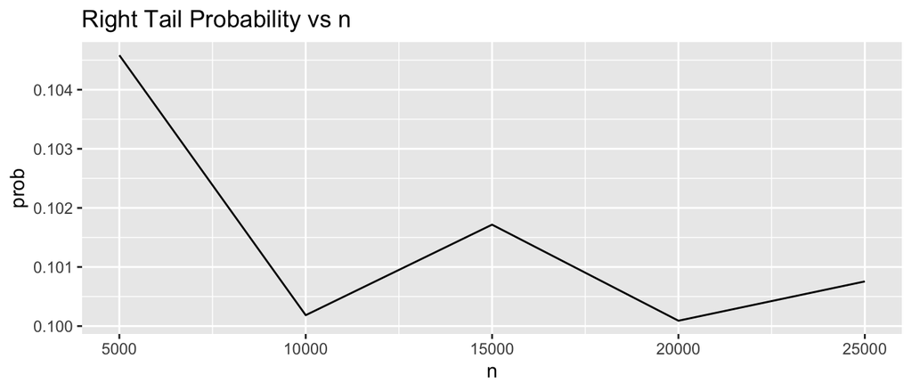

```r
# insert code below

ggplot(result_filtered, aes(x = n, y = prob)) +
  geom_line() +
  xlab("n") +
  ylab("prob") +
  ggtitle("Right Tail Probability vs n")
```

#### 5E

What is the average of the values of `prob` for $n > 15,000$?

```r
# insert code below


filtered_data <- result_filtered %>%
  filter(n > 15000)

average_prob_for_n_gt_15000 <- mean(filtered_data$prob)

cat("Average of 'prob' values for n > 15,000:", average_prob_for_n_gt_15000, "\n")
```

```
## Average of 'prob' values for n > 15,000: 0.1004232
```